# Machine Learning Course Project - Andy Pickering

## Executive Summary

Accelerometer data from subjects performing barbell lifts is used to predict the manner in which they did the exercise. A machine learning model is used to make this prediction. The final model is a random forest model and has an out-of sample accuracy of 0.99 . This analysis is part of the JHU Machine Learning course on Coursera.

## Project Description

Using devices such as Jawbone Up, Nike FuelBand, and Fitbit it is now possible to collect a large amount of data about personal activity relatively inexpensively. These type of devices are part of the quantified self movement – a group of enthusiasts who take measurements about themselves regularly to improve their health, to find patterns in their behavior, or because they are tech geeks. One thing that people regularly do is quantify how much of a particular activity they do, but they rarely quantify how well they do it. In this project, your goal will be to use data from accelerometers on the belt, forearm, arm, and dumbell of 6 participants. They were asked to perform barbell lifts correctly and incorrectly in 5 different ways. More information is available from the website here: http://groupware.les.inf.puc-rio.br/har (see the section on the Weight Lifting Exercise Dataset).

## Data

The training data for this project are available here: https://d396qusza40orc.cloudfront.net/predmachlearn/pml-training.csv

The test data are available here: https://d396qusza40orc.cloudfront.net/predmachlearn/pml-testing.csv

The data for this project come from this source: http://groupware.les.inf.puc-rio.br/har. The citation for this dataset is:

Velloso, E.; Bulling, A.; Gellersen, H.; Ugulino, W.; Fuks, H. Qualitative Activity Recognition of Weight Lifting Exercises. Proceedings of 4th International Conference in Cooperation with SIGCHI (Augmented Human ’13) . Stuttgart, Germany: ACM SIGCHI, 2013.

The goal of the project is to predict the manner in which they did the exercise. This is the “classe” variable in the training set.

First the data is downloaded and read into R:

```r
rm(list=ls())
url_train<-"https://d396qusza40orc.cloudfront.net/predmachlearn/pml-training.csv"
url_test <- "https://d396qusza40orc.cloudfront.net/predmachlearn/pml-testing.csv"
# download data
#download.file(url_train,"training_data")
#download.file(url_test,"testing_data")
# load data (already downloaded)
train_data <- read.csv("training_data")
test_data <- read.csv("testing_data")
dim(train_data)
```

```
[1] 19622   160
```

There are 19622 observations and 160 variables. The data is split into training/test sets based on the ‘classe’ variable we are trying to predict:

```r
suppressPackageStartupMessages(library(caret))
inTrain <- createDataPartition(y=train_data$classe,p=0.75,list=FALSE)
training_set <- train_data[inTrain,]
testing_set <- train_data[-inTrain,]
dim(training_set)
```

```
[1] 14718   160
```

```r
dim(testing_set)
```

```
[1] 4904  160
```

First I removed fields which I don’t want to use to predict, including user names and timestamps.

```r
# remove fields we don't want to use for predicting
idb <- which(names(train_data) %in% c("X","user_name","raw_timestamp_part_1","raw_timestamp_part_2","cvtd_timestamp","new_window","num_window" ) )
training_set <- training_set[,-idb]
dim(training_set)
```

```
[1] 14718   153
```

```r
# remove same variables from testing_set also
idb <- which(names(testing_set) %in% c("X","user_name","raw_timestamp_part_1","raw_timestamp_part_2","cvtd_timestamp","new_window","num_window" ) )
testing_set <- testing_set[,-idb]
dim(testing_set)
```

```
[1] 4904  153
```

```r
# and from 'test_data' which we will predict for the quiz
# remove same variables from testing_set also
idb <- which(names(test_data) %in% c("X","user_name","raw_timestamp_part_1","raw_timestamp_part_2","cvtd_timestamp","new_window","num_window" ) )
test_data <- test_data[,-idb]
dim(test_data)
```

```
[1]  20 153
```

```r
# check which variables are zero/near-zero variance
library(caret)
bad_vars <- nearZeroVar(training_set)
names(training_set)[bad_vars]
```

```
 [1] "kurtosis_roll_belt"      "kurtosis_picth_belt"
 [3] "kurtosis_yaw_belt"       "skewness_roll_belt"
 [5] "skewness_roll_belt.1"    "skewness_yaw_belt"
 [7] "max_yaw_belt"            "min_yaw_belt"
 [9] "amplitude_yaw_belt"      "avg_roll_arm"
[11] "stddev_roll_arm"         "var_roll_arm"
[13] "avg_pitch_arm"           "stddev_pitch_arm"
[15] "var_pitch_arm"           "avg_yaw_arm"
[17] "stddev_yaw_arm"          "var_yaw_arm"
[19] "kurtosis_roll_arm"       "kurtosis_picth_arm"
[21] "kurtosis_yaw_arm"        "skewness_roll_arm"
[23] "skewness_pitch_arm"      "skewness_yaw_arm"
[25] "amplitude_roll_arm"      "kurtosis_roll_dumbbell"
[27] "kurtosis_picth_dumbbell" "kurtosis_yaw_dumbbell"
[29] "skewness_roll_dumbbell"  "skewness_pitch_dumbbell"
[31] "skewness_yaw_dumbbell"   "max_yaw_dumbbell"
[33] "min_yaw_dumbbell"        "amplitude_yaw_dumbbell"
[35] "kurtosis_roll_forearm"   "kurtosis_picth_forearm"
[37] "kurtosis_yaw_forearm"    "skewness_roll_forearm"
[39] "skewness_pitch_forearm"  "skewness_yaw_forearm"
[41] "max_yaw_forearm"         "min_yaw_forearm"
[43] "amplitude_yaw_forearm"   "stddev_roll_forearm"
[45] "var_roll_forearm"        "avg_pitch_forearm"
[47] "stddev_pitch_forearm"    "var_pitch_forearm"
[49] "avg_yaw_forearm"         "stddev_yaw_forearm"
[51] "var_yaw_forearm"
```

```r
# remove these data from the training set
training_set_2 <- training_set[, -c(bad_vars)]
# remove from test set also
testing_set_2  <- testing_set [, -c(bad_vars)]
dim(training_set_2)
```

```
[1] 14718   102
```

```r
# and from test_data
test_data  <- test_data [, -c(bad_vars)]
dim(training_set_2)
```

```
[1] 14718   102
```

Next I do some exploratory analysis of data and predictors

```r
# see if classes are balanced
table(training_set_2$classe)
```

```
   A    B    C    D    E
4185 2848 2567 2412 2706
```

```r
# What percent is the dominant class?
4185/nrow(training_set)*100
```

```
[1] 28.43457
```

The dominant class is ‘A’, and it’s fraction is about 28%. Thus, any model we construct should have an accuracy higher than this.

Next I look at how many NAs are in the data, and use knn-impute to deal with these.

```r
# Check if some variables have NAs
nas<-lapply(training_set,is.na)
sumna<-lapply(nas,sum)
```

Deal with NAs using knn-imputation prior to training

```r
pp<-preProcess(training_set_2,method="knnImpute")
# apply to training values
training_set_3 <- predict(pp,training_set_2)
```

```
named arguments other than 'exact' are discouraged
```

```r
# apply to testing set also now, for future comparison after building models on training set
testing_set_3 <- predict(pp, testing_set_2)
# and test_data
test_data <- predict(pp, test_data)
```

```r
library(caret)
myFolds <- createFolds(training_set_3$classe, k = 5)
#myControl=trainControl(method="cv", number=5)
myControl=trainControl(classProbs = TRUE, # IMPORTANT!
                       verboseIter = FALSE,
                       savePredictions = TRUE,
                       index=myFolds)
```

### Summary of Data Preparation and Pre-processing

- Data is partitioned into training and test sets, based on the ‘classe’ variable.
- Variables such as username and timestamps are removed since we don’t want to use these to predict.
- Variables with near-zero variance in training data are removed.
- NAs are imputed using k-neareast-neighbors.
- Above pre-processing steps are applied to the test data.

## Model Training

#### knn model

```r
library(caret)
ptm <- proc.time()
mod_knn <- train(classe~.,
              method="knn",
              data=training_set_3,
              trControl=myControl)
print(mod_knn)
```

```
k-Nearest Neighbors

14718 samples
  101 predictor
    5 classes: 'A', 'B', 'C', 'D', 'E'

No pre-processing
Resampling: Bootstrapped (5 reps)
Summary of sample sizes: 2943, 2944, 2944, 2943, 2944
Resampling results across tuning parameters:

  k  Accuracy   Kappa
  5  0.8269977  0.7812054
  7  0.8033193  0.7513151
  9  0.7841252  0.7270481

Accuracy was used to select the optimal model using  the
 largest value.
The final value used for the model was k = 5.
```

```r
elaps_time <- proc.time() - ptm
print(elaps_time/60)
```

```
      user     system    elapsed
2.57823333 0.01366667 2.59810000
```

#### rpart model

```r
library(caret)
ptm <- proc.time()
# rpart
mod_rpart <- train(classe~.,
              method="rpart",
              data=training_set_3,
              trControl=myControl)
print(mod_rpart)
```

```
CART

14718 samples
  101 predictor
    5 classes: 'A', 'B', 'C', 'D', 'E'

No pre-processing
Resampling: Bootstrapped (5 reps)
Summary of sample sizes: 2943, 2944, 2944, 2943, 2944
Resampling results across tuning parameters:

  cp          Accuracy   Kappa
  0.04202665  0.5232361  0.39419941
  0.04357733  0.4171440  0.21831917
  0.11601633  0.3168906  0.04955547

Accuracy was used to select the optimal model using  the
 largest value.
The final value used for the model was cp = 0.04202665.
```

```r
elaps_time <- proc.time() - ptm
print(elaps_time/60)
```

```
     user    system   elapsed
0.1841500 0.0185500 0.2031333
```

#### Random forest model

```r
library(caret)
# time how long it takes
ptm <- proc.time()
mod_rf <- train(classe~.,
              method="rf",
              data=training_set_3,
              trControl=myControl)
print(mod_rf)
```

```
Random Forest

14718 samples
  101 predictor
    5 classes: 'A', 'B', 'C', 'D', 'E'

No pre-processing
Resampling: Bootstrapped (5 reps)
Summary of sample sizes: 2943, 2944, 2944, 2943, 2944
Resampling results across tuning parameters:

  mtry  Accuracy   Kappa
    2   0.9204547  0.8993442
   51   0.9542397  0.9420952
  101   0.9501120  0.9368787

Accuracy was used to select the optimal model using  the
 largest value.
The final value used for the model was mtry = 51.
```

```r
# print time to fit model
elaps_time <- proc.time() - ptm
print(elaps_time/60)
```

```
      user     system    elapsed
6.75288333 0.08751667 6.93186667
```

#### ‘ranger’ (another random forest package, which is supposed to run faster but give similar results)

```r
ptm <- proc.time()
# RF, no pre-proc, omit NAs
mod_ranger <- train(classe~.,
              method="ranger",
              data=training_set_3,
              trControl=myControl)
print(mod_ranger)
```

```
Random Forest

14718 samples
  101 predictor
    5 classes: 'A', 'B', 'C', 'D', 'E'

No pre-processing
Resampling: Bootstrapped (5 reps)
Summary of sample sizes: 2943, 2944, 2944, 2943, 2944
Resampling results across tuning parameters:

  mtry  Accuracy   Kappa
    2   0.9063903  0.8815241
   51   0.9519466  0.9391987
  101   0.9457976  0.9314294

Accuracy was used to select the optimal model using  the
 largest value.
The final value used for the model was mtry = 51.
```

```r
elaps_time <- proc.time() - ptm
print(elaps_time/60)
```

```
     user    system   elapsed
9.8103333 0.1380667 3.3017667
```

## Comparison of models.

The models are then directly compared to choose the best-performing one. I learned this procedure from the ‘Machine Learning Toolbox’ course on DataCamp.

```r
model_list <- list(item1 = mod_knn, item2=mod_rpart, item3 = mod_rf, item4 = mod_ranger)
# Pass model_list to resamples(): resamples
resamples <- resamples(model_list,modelNames=c("knn","rpart","rf","ranger"))
# Summarize the results
summary(resamples)
```

```
Call:
summary.resamples(object = resamples)

Models: knn, rpart, rf, ranger
Number of resamples: 5

Accuracy
         Min. 1st Qu. Median   Mean 3rd Qu.   Max. NA's
knn    0.8200  0.8251 0.8272 0.8270  0.8292 0.8334    0
rpart  0.4753  0.5100 0.5369 0.5232  0.5380 0.5559    0
rf     0.9513  0.9520 0.9535 0.9542  0.9553 0.9591    0
ranger 0.9501  0.9504 0.9507 0.9519  0.9535 0.9551    0

Kappa
         Min. 1st Qu. Median   Mean 3rd Qu.   Max. NA's
knn    0.7725  0.7786 0.7817 0.7812  0.7839 0.7894    0
rpart  0.3461  0.3681 0.4090 0.3942  0.4115 0.4363    0
rf     0.9384  0.9393 0.9411 0.9421  0.9435 0.9482    0
ranger 0.9368  0.9372 0.9377 0.9392  0.9411 0.9432    0
```

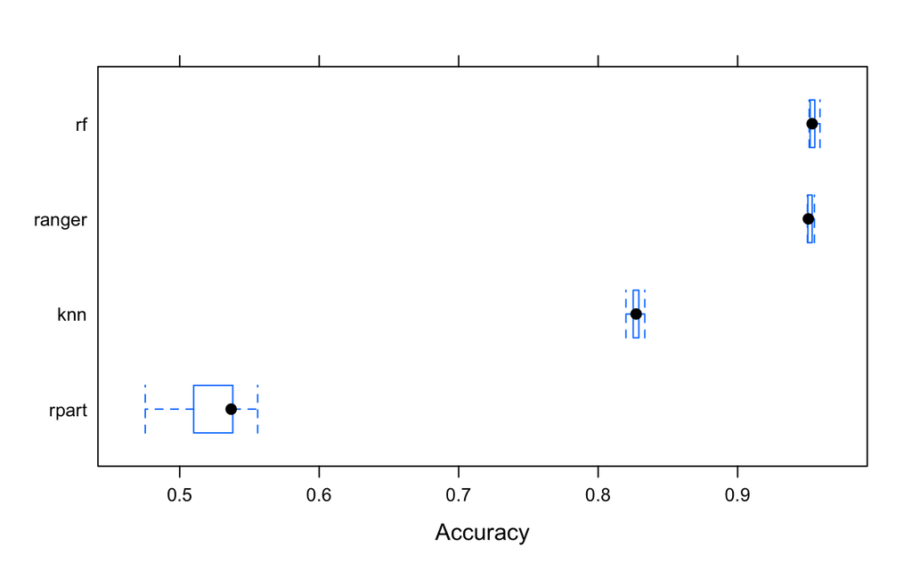

```r
bwplot(resamples,metric="Accuracy")
```

From the above comparison, the ‘rf’ random forest model had the highest training-set accuracy. This model is now evaluated on the testing set to estimate the out-of-sample accuracy.

```r
preds_final <- predict(mod_rf,testing_set_3)
confusionMatrix(preds_final,testing_set_3$classe)
```

```
Confusion Matrix and Statistics

          Reference
Prediction    A    B    C    D    E
         A 1390    4    0    1    0
         B    5  941   11    0    1
         C    0    4  839   17    2
         D    0    0    5  784    3
         E    0    0    0    2  895

Overall Statistics

               Accuracy : 0.9888
                 95% CI : (0.9854, 0.9915)
    No Information Rate : 0.2845
    P-Value [Acc > NIR] : < 2.2e-16

                  Kappa : 0.9858
 Mcnemar's Test P-Value : NA

Statistics by Class:

                     Class: A Class: B Class: C Class: D Class: E
Sensitivity            0.9964   0.9916   0.9813   0.9751   0.9933
Specificity            0.9986   0.9957   0.9943   0.9980   0.9995
Pos Pred Value         0.9964   0.9823   0.9733   0.9899   0.9978
Neg Pred Value         0.9986   0.9980   0.9960   0.9951   0.9985
Prevalence             0.2845   0.1935   0.1743   0.1639   0.1837
Detection Rate         0.2834   0.1919   0.1711   0.1599   0.1825
Detection Prevalence   0.2845   0.1954   0.1758   0.1615   0.1829
Balanced Accuracy      0.9975   0.9936   0.9878   0.9866   0.9964
```

## Conclusions

- Of the models tried, the two random forest models had the highest accuracy. The model fit with the “rf” package had a slightly higher accuracy than the “ranger” model, but took longer to run.
- The “rf” model was chosen as the final model. On the training set, it had an accuracy of 0.95. On the test set, it had an accuracy of 0.99.